# 1. 이용자 분석

## 연령대와 성별로 사용자 이용 현황을 파악할 수 있다.

### 20대와 30대가 주 이용층이고, 여자보다는 남자가 더 많이 이용한다.

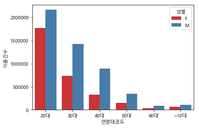

```python
sns.barplot(x = '연령대코드',y = '이용건수' ,data =  df2, hue ='성별',palette="Set1" )
```

## 2017년 공공자전거 회원가입수와 이용건수를 비교한 결과

### 1.여자보다 남자가 가입후 실제 이용률이 높았다.

### 2.연령대가 증가할 수록 가입후 실제 이용률 역시 증가했다.

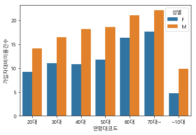

```python
sns.barplot(x ='연령대코드', y = '가입자대비이용건수' ,data = df,hue='성별',)
```

## 정기권을 쓰는 이용자가 일일권이용자보다 3배정도 많고,

## 정기권을 쓰는 사람들은 주말보다 주중에 공공자전거를 더 많이 이용한다.

## 단체와 일일권이용자는 주중보다 주말에 공공자전거를 더 많이 이용한다.

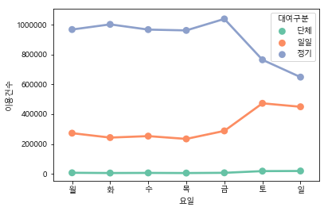

```python
sns.pointplot(x = '요일',y = '이용건수' ,data =  df3, hue ='대여구분',palette="Set2" )
```

# 2. 전체 이용량과 월별 분석

## 2017년에 비해 2018년의 공공자전거 이용 대수가 2배 이상 늘어난 것을 확인 할 수 있다.

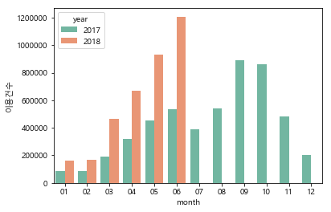

```python
sns.barplot(x ='month', y = '이용건수' ,data = df1 , hue='year',palette="Set2")
```

# 3. 시간대별 분석

```python
df.groupby('경로').count().sort_values('대여일시',axis = 0, ascending = False).head(10)
```

| 경로 | 대여일시 | 대여대여소번호번호 | 대여대여소 | 반납일시 | 반납대여소번호 | 반납대여소 | year | month | 대여시간 | 반납시간 |
| --- | --- | --- | --- | --- | --- | --- | --- | --- | --- | --- |
| 여의나루역 1번출구 앞- 여의나루역 1번출구 앞 | 18472 | 18380 | 18472 | 18472 | 18472 | 18472 | 18472 | 18472 | 18472 | 18472 |
| 뚝섬유원지역 1번출구 앞- 뚝섬유원지역 1번출구 앞 | 13268 | 13202 | 13268 | 13268 | 13268 | 13268 | 13268 | 13268 | 13268 | 13268 |
| 월드컵공원- 월드컵공원 | 8096 | 8026 | 8096 | 8096 | 8096 | 8096 | 8096 | 8096 | 8096 | 8096 |
| 서울숲역 4번 출구 옆- 서울숲역 4번 출구 옆 | 7182 | 7113 | 7182 | 7182 | 7182 | 7182 | 7182 | 7182 | 7182 | 7182 |
| 마포구민체육센터 앞- 마포구민체육센터 앞 | 6334 | 6307 | 6334 | 6334 | 6334 | 6334 | 6334 | 6334 | 6334 | 6334 |
| 하늘채코오롱아파트 건너편- 홍대입구역 2번출구 앞 | 5894 | 5733 | 5894 | 5894 | 5894 | 5894 | 5894 | 5894 | 5894 | 5894 |
| 홍대입구역 2번출구 앞- 하늘채코오롱아파트 건너편 | 4575 | 4461 | 4575 | 4575 | 4575 | 4575 | 4575 | 4575 | 4575 | 4575 |
| 옥수역 3번출구- 옥수역 3번출구 | 4341 | 4307 | 4341 | 4341 | 4341 | 4341 | 4341 | 4341 | 4341 | 4341 |
| 외국어대 정문 앞- 외국어대 정문 앞 | 4045 | 4015 | 4045 | 4045 | 4045 | 4045 | 4045 | 4045 | 4045 | 4045 |
| 당산육갑문- 당산육갑문 | 3919 | 3905 | 3919 | 3919 | 3919 | 3919 | 3919 | 3919 | 3919 | 3919 |

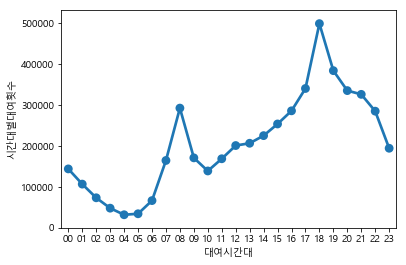

```python
sns.pointplot(x = byTime.index, y = '시간대별대여횟수', data = byTime)
```

## 겨울의 대여 시간 분포

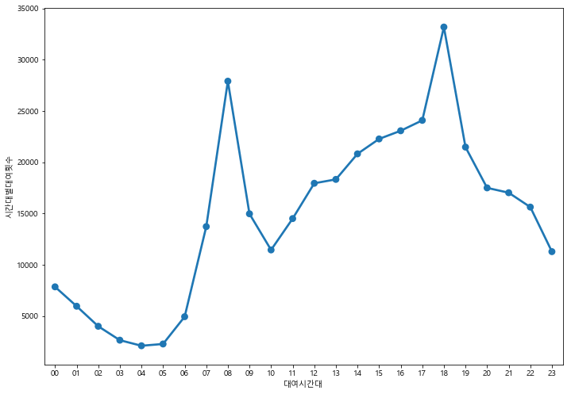

```python
a4_dims = (11.7, 8.27)
fig, ax = pyplot.subplots(figsize=a4_dims)
sns.pointplot(x = winterByMBT.index, y = '시간대별대여횟수', data = winterByMBT,size = 0.7,ax = ax)
```

## 겨울의 반납시간 분포

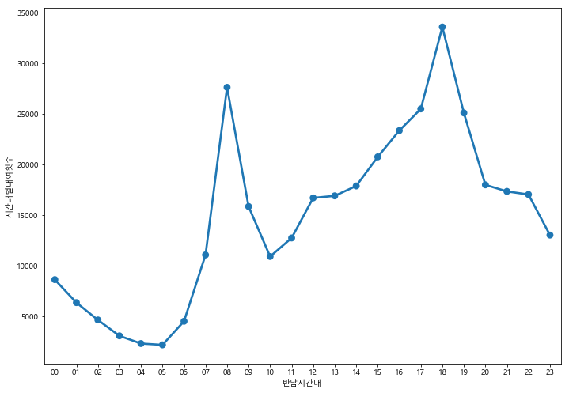

```python
a4_dims = (11.7, 8.27)
fig, ax = pyplot.subplots(figsize=a4_dims)
sns.pointplot(x = winterByMRT.index, y = '시간대별대여횟수', data = winterByMRT,size = 0.7,ax = ax)
```

## 가을의 대여시간 분포

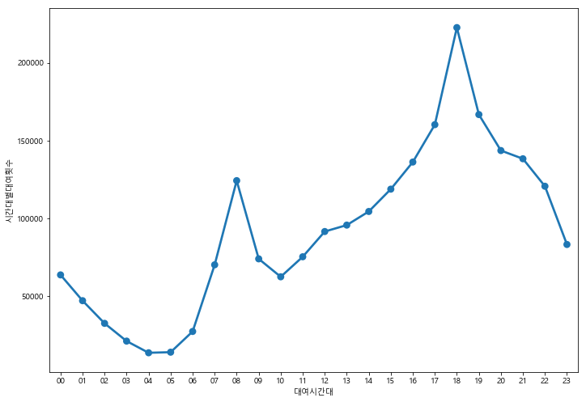

```python
a4_dims = (11.7, 8.27)
fig, ax = pyplot.subplots(figsize=a4_dims)
sns.pointplot(x = fallByMBT.index, y = '시간대별대여횟수', data = fallByMBT,size = 0.7,ax = ax)
```

## 가을의 반납시간 분포

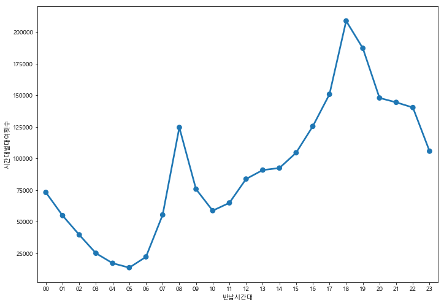

```python
a4_dims = (11.7, 8.27)
fig, ax = pyplot.subplots(figsize=a4_dims)
sns.pointplot(x = fallByMRT.index, y = '시간대별대여횟수', data = fallByMRT,size = 0.7,ax = ax)
```

## 가을과 겨울의 반납시간 분포

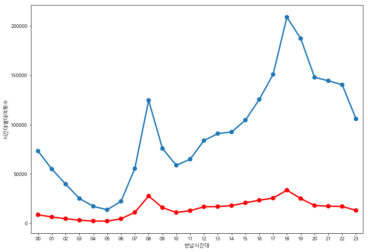

```python
a4_dims = (11.7, 8.27)
fig, ax = pyplot.subplots(figsize=a4_dims)
sns.pointplot(x = fallByMRT.index, y = '시간대별대여횟수', data = fallByMRT,size = 0.7,ax = ax)
sns.pointplot(x = winterByMRT.index, y = '시간대별대여횟수',color = 'r', data = winterByMRT,size = 0.7,ax = ax)
```

## 가을과 겨울의 대여시간 분포

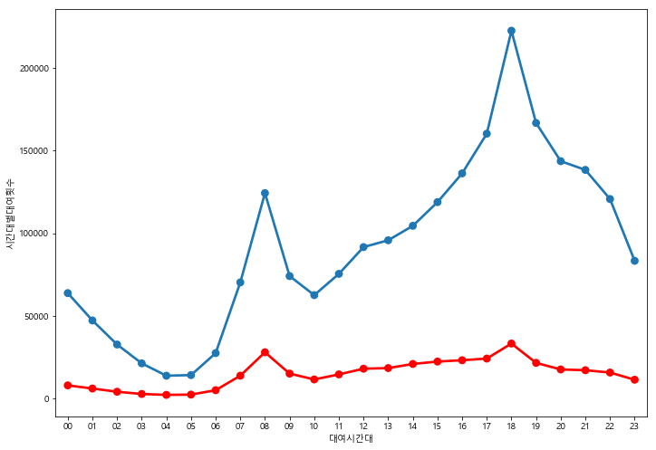

```python
a4_dims = (11.7, 8.27)
fig, ax = pyplot.subplots(figsize=a4_dims)
sns.pointplot(x = fallByMBT.index, y = '시간대별대여횟수', data = fallByMBT,size = 0.7,ax = ax)
sns.pointplot(x = winterByMBT.index, y = '시간대별대여횟수',color = 'r', data = winterByMBT,size = 0.7,ax = ax)
```

[figure not shown]

```python
a4_dims = (11.7, 8.27)
fig, ax = pyplot.subplots(figsize=a4_dims)
sns.pointplot(x = fallByMRT.index, y = '시간대별대여횟수', data = fallByMRT,size = 0.7,ax = ax)
sns.pointplot(x = fallByMBT.index, y = '시간대별대여횟수',color = 'r', data = fallByMRT,size = 0.7,ax = ax)
```

## 겨울의 대여시간과 반납시간의 분포

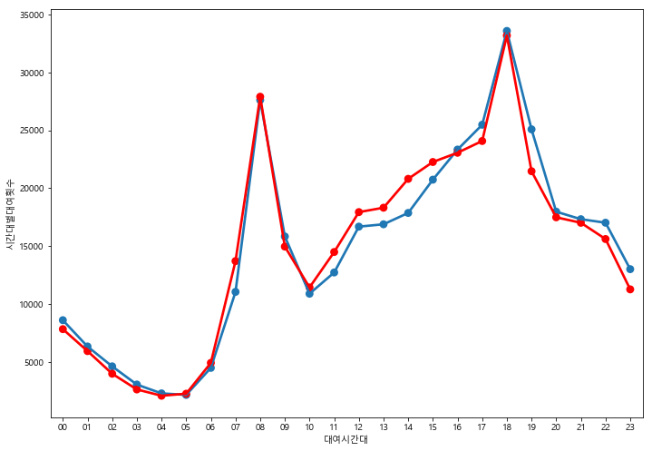

```python
a4_dims = (11.7, 8.27)
fig, ax = pyplot.subplots(figsize=a4_dims)
sns.pointplot(x = winterByMRT.index, y = '시간대별대여횟수', data = winterByMRT,size = 0.7,ax = ax)
sns.pointplot(x = winterByMBT.index, y = '시간대별대여횟수',color = 'r', data = winterByMBT,size = 0.7,ax = ax)
```

# 4. 대여소별 이용 분석

### 2017년부터 이용건수 합을 구별로 나타낸 결과,

### 가장 이용을 많이하는 구는 마포구, 영등포구, 종로구, 성동구, 광진구이다.

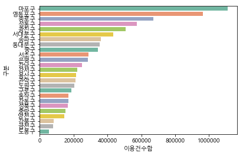

```python
sns.barplot(y = df3.index,x = '이용건수합' ,data =  df3, palette="Set2")
```

### 가장 이용을 많이 한 8개 구별 이용건수의 분산을 구한 결과

### 한강이 있는 구는 분산이 크고 한강이 없는 구는 분산이 작은 경향이 있다.

### 즉,한강이 있는 구는 한강 주변에 있는 대여소를 많이 이용해서 대여소별 이용차이가 커졌고,

### 한강이 없는 구는 대여소들을 골고루 이용하여 대여소별 이용차이가 작다고 할 수 있다.

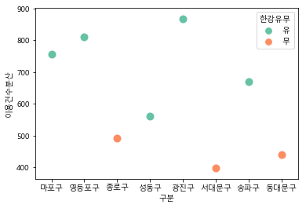

```python
sns.swarmplot(x ='구분',y ='이용건수분산',hue='한강유무',data = df6,size = 10,palette="Set2")
```

### 한강이 있는 마포구의 2018년 6월 대여소별 이용건수를 보면 대여소별로 이용건수 차이가 커서 길쭉한 그래프가 그려졌고,

### 한강이 없는 종로구는 대여소 별로 이용건수 차이가 작아서 옆으로 넓은 그래프가 나타났다.

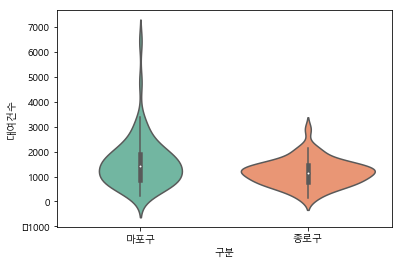

```python
sns.violinplot(data=df10,y='대여건수',x = '구분',palette="Set2")
```